Skip to main content

# Does the ring differ from systemic methods in host gene expression? (Study B)

> **What this document is.** The ring delivers contraceptive hormone locally; the pill and the injectable act systemically. If the local dose matters, the vaginal tissue under the ring should show a different host-transcriptome profile. This morning we start with an **ordination of the genes** to see the shape of the data before any test, then run a **differential-expression analysis with DESeq2** comparing ring against the two systemic methods pooled. Full data QC lives in `01-qc.html`; this document repeats only the checks this analysis depends on.

```r
library(tidyverse)
library(here)
library(DESeq2)
library(microViz)
library(phyloseq)
library(vegan)      # PERMANOVA (adonis2)
library(patchwork)
library(ggrepel)    # labels that do not overlap

source(here("R/count_tables.R"))

d  <- read_counts("group_b")
ge <- d$genes          # 14,226 genes x 93 samples, RAW counts
md <- d$metadata       # one row per sample, same order as columns

# The two groups for the main question. Defined from the METADATA table,
# never from the count table we are about to test.
md <- md |> mutate(arm_group = if_else(arm == "ring", "ring", "systemic"))
```

# 1. QC for this analysis

```r
stopifnot(identical(colnames(ge), md$sample_id))   # order check: DESeq2 would fail silently

batch_balance <- md |> dplyr::count(arm, rnaseq_batch) |>
  pivot_wider(names_from = rnaseq_batch, values_from = n, values_fill = 0)
knitr::kable(batch_balance, caption = "Samples per arm and sequencing batch")
```

Samples per arm and sequencing batch

| arm | B1 | B2 |
| --- | --- | --- |
| injectable | 20 | 19 |
| pill | 14 | 14 |
| ring | 13 | 13 |

- **Order check passed:** count-matrix columns and metadata rows are in the same `sample_id` order. DESeq2 does not warn if they differ — it would just be wrong.
- **Balance:** every arm appears in both sequencing batches (ring 13/13, pill 14/14, injectable 20/19), so batch can go into the design as a covariate without confounding the contrast.
- **Carried flags from `01-qc.html`:** `B093` carries heavy blood signal (about a third of its reads are HBB/HBA); `B018`/`B029` lack cytokines (irrelevant here). Vaginal pH differs slightly across arms (p = 0.02) — a possible confounder to remember when reading results.

# 2. Ordination: do the samples separate by arm?

We keep genes with at least 10 reads in at least 10 samples, transform to CLR (centred log-ratio — log-ratios of each gene against the geometric mean of the sample, which is the standard way to handle compositional RNA-seq profiles in ordination), and draw a Euclidean PCoA.

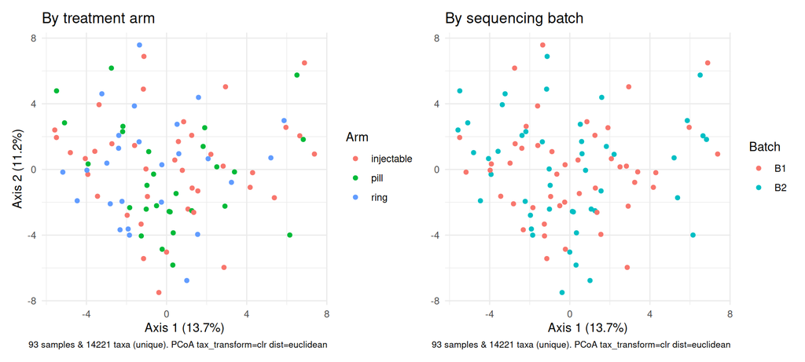

```r
ps_genes <- as_counts(dataset = "group_b", table = "rnaseq",
                      min_count = 10, min_samples = 10, data = d)
sd <- as(sample_data(ps_genes), "data.frame")
idx <- match(sd$sample_id, md$sample_id)
sd$arm       <- md$arm[idx]
sd$arm_group <- md$arm_group[idx]
sample_data(ps_genes) <- sample_data(sd)

ord <- ps_genes |>
  tax_transform("clr", zero_replace = "halfmin") |>
  dist_calc("euclidean") |>
  ord_calc("PCoA")

eig <- attr(ord, "ord")$CA$eig
sh  <- round(100 * eig / sum(eig), 1)

p_arm   <- ord_plot(ord, axes = 1:2, color = "arm") +
  labs(title = "By treatment arm", x = sprintf("Axis 1 (%s%%)", sh[1]),
       y = sprintf("Axis 2 (%s%%)", sh[2]), color = "Arm")
p_batch <- ord_plot(ord, axes = 1:2, color = "rnaseq_batch") +
  labs(title = "By sequencing batch", x = sprintf("Axis 1 (%s%%)", sh[1]),
       y = NULL, color = "Batch")
p_arm + p_batch
```

```r
# PERMANOVA: does the distance between samples depend on arm / batch?
# Same CLR+Euclidean distances as the plot above.
dm <- attr(ord, "dist")
meta_p <- sd[rownames(as.matrix(dm)), ]
set.seed(1)
per_arm   <- adonis2(dm ~ arm_group, data = meta_p, permutations = 999)
per_batch <- adonis2(dm ~ rnaseq_batch, data = meta_p, permutations = 999)

knitr::kable(
  tibble(
    term     = c("arm_group", "rnaseq_batch"),
    R2_pct   = round(100 * c(per_arm$R2[1], per_batch$R2[1]), 1),
    p_value  = c(per_arm$`Pr(>F)`[1], per_batch$`Pr(>F)`[1])
  ),
  caption = "PERMANOVA on CLR + Euclidean distances (999 permutations)"
)
```

PERMANOVA on CLR + Euclidean distances (999 permutations)

| term | R2_pct | p_value |
| --- | --- | --- |
| arm_group | 1.7 | 0.040 |
| rnaseq_batch | 1.4 | 0.107 |

```r
n_kept <- nrow(otu_table(ps_genes))
```

The gene table keeps 14221 of 14,226 genes after the filter. The ordination plot shows no separation by arm that the eye can pick up, but PERMANOVA — which tests whether sample-to-sample distances depend on a variable, using permutation p-values — puts a small but real **1.7 % of the variation on `arm_group` (p = 0.040)**, while sequencing batch accounts for a similar 1.4 % that is **not** significant (p = 0.107). That is the honest first answer to this morning’s question: the ring’s effect on the overall host-expression profile is subtle — detectable by a permutation test, not by looking at the map. Individual genes may still shift clearly, which is what DESeq2 tests next.

# 3. Differential expression: ring vs systemic

DESeq2 models **raw counts** (it does its own size-factor normalisation and dispersion shrinkage). Never give it CPM or logged values.

```r
genes_f <- ge[rowSums(ge >= 10) >= 10, ]     # same filter as the ordination
rownames(md) <- md$sample_id

dds <- DESeqDataSetFromMatrix(genes_f, md, design = ~ rnaseq_batch + arm_group)
dds <- DESeq(dds)
res <- results(dds, contrast = c("arm_group", "ring", "systemic"))

res_df <- as.data.frame(res) |>
  rownames_to_column("ensembl_gene_id") |>
  left_join(d$gene_info |> select(ensembl_gene_id, symbol),
            by = "ensembl_gene_id") |>
  mutate(symbol = coalesce(symbol, ensembl_gene_id),
         padj   = replace_na(padj, 1))

sig <- res_df |> filter(padj < 0.05)
```

```r
knitr::kable(
  tibble(
    quantity = c("genes tested", "FDR < 0.05", "up in ring (FDR < 0.05)",
                 "down in ring (FDR < 0.05)", "smallest FDR"),
    value = c(nrow(res_df), nrow(sig),
              sum(sig$log2FoldChange > 0), sum(sig$log2FoldChange < 0),
              format(min(res_df$padj), digits = 2))
  ),
  caption = "DESeq2 results, ring vs systemic"
)
```

DESeq2 results, ring vs systemic

| quantity | value |
| --- | --- |
| genes tested | 14221 |
| FDR < 0.05 | 165 |
| up in ring (FDR < 0.05) | 88 |
| down in ring (FDR < 0.05) | 77 |
| smallest FDR | 2.6e-09 |

# 4. What do the hits look like?

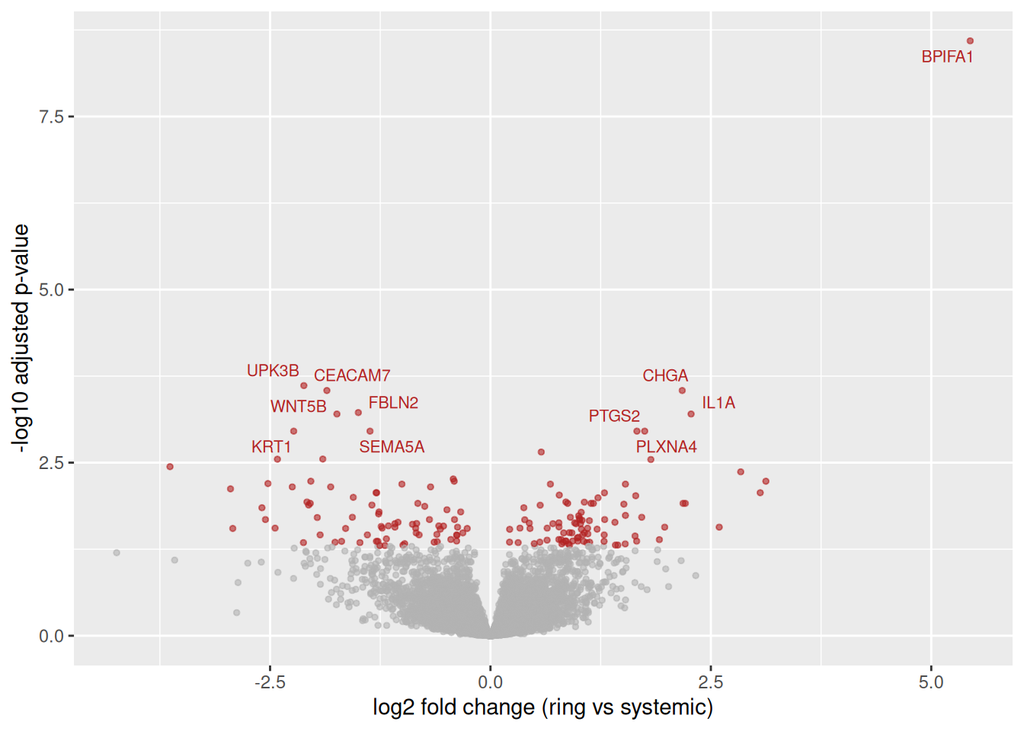

Volcano plot. Red: FDR < 0.05. Labels: the 10 smallest FDR values.

```r
res_df |>
  mutate(hit = padj < 0.05,
         label = if_else(rank(padj) <= 10, symbol, NA_character_)) |>
  ggplot(aes(log2FoldChange, -log10(padj), colour = hit)) +
  geom_point(size = 1, alpha = 0.6, show.legend = FALSE) +
  scale_colour_manual(values = c("grey70", "firebrick")) +
  geom_text_repel(aes(label = label), size = 2.8, max.overlaps = 20,
                  show.legend = FALSE) +
  labs(x = "log2 fold change (ring vs systemic)",
       y = "-log10 adjusted p-value")
```

```r
top <- sig |> slice_min(padj, n = 15) |>
  transmute(symbol, log2FC = round(log2FoldChange, 2),
            FDR = signif(padj, 2))
knitr::kable(top, caption = "15 smallest-FDR genes, ring vs systemic")
```

15 smallest-FDR genes, ring vs systemic

| symbol | log2FC | FDR |
| --- | --- | --- |
| BPIFA1 | 5.44 | 0.00000 |
| UPK3B | -2.12 | 0.00024 |
| CHGA | 2.18 | 0.00029 |
| CEACAM7 | -1.86 | 0.00029 |
| FBLN2 | -1.50 | 0.00060 |
| IL1A | 2.28 | 0.00063 |
| WNT5B | -1.74 | 0.00063 |
| PTGS2 | 1.66 | 0.00110 |
| SEMA5A | -1.37 | 0.00110 |
| PLXNA4 | 1.75 | 0.00110 |
| KRT1 | -2.23 | 0.00110 |
| CLIC4 | 0.58 | 0.00220 |
| PSCA | -1.90 | 0.00280 |
| MT1G | -2.42 | 0.00280 |
| KDR | 1.82 | 0.00290 |

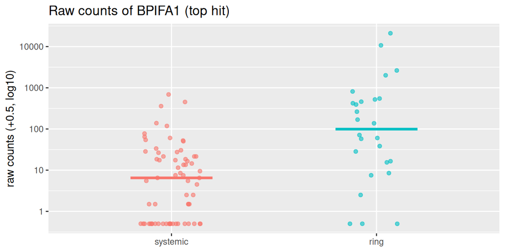

Raw counts of the top hit per sample. Each dot is one sample; y-axis is log10.

```r
top_gene <- sig |> slice_min(padj, n = 1) |> pull(ensembl_gene_id)
plot_df  <- md |>
  mutate(counts = ge[top_gene, ]) |>
  mutate(arm_group = factor(arm_group, c("systemic", "ring")))
ggplot(plot_df, aes(arm_group, counts + 0.5, colour = arm_group)) +
  geom_jitter(width = 0.15, alpha = 0.6, show.legend = FALSE) +
  stat_summary(fun = median, geom = "crossbar", width = 0.4, show.legend = FALSE) +
  scale_y_log10() +
  labs(title = str_c("Raw counts of ", top$symbol[1], " (top hit)"),
       x = NULL, y = "raw counts (+0.5, log10)")
```

# 5. Sensitivity: does B093 drive the result?

`B093`’s blood signal could masquerade as a ring effect if it happened to sit in one arm. We refit without it and count how many of the main hits survive.

```r
md_s <- md |> filter(sample_id != "B093")
dds_s <- DESeqDataSetFromMatrix(genes_f[, md_s$sample_id], md_s,
                                design = ~ rnaseq_batch + arm_group)
dds_s <- DESeq(dds_s)
res_s <- results(dds_s, contrast = c("arm_group", "ring", "systemic")) |>
  as.data.frame() |>
  rownames_to_column("ensembl_gene_id")

survive <- sig |>
  inner_join(res_s |> filter(padj < 0.05), by = "ensembl_gene_id")
```

Of the 165 genes significant in the main fit, 152 remain significant at FDR < 0.05 after dropping `B093` (92% survival). Low survival would mean the top hits lean on one blood-contaminated sample; high survival means the result is spread across samples.

# 6. Verdict

- The gene-table ordination shows **no separation by arm that the eye can see**, but PERMANOVA finds `arm_group` explains a small, significant share of the variation (**1.7 %, p = 0.04**); sequencing batch is similar in size (1.4 %) and not significant.
- DESeq2 finds **165 genes at FDR < 0.05** for ring vs systemic (88 up in ring). Inspect the top hits’ biology before believing any single one — with 14221 genes tested, hits at the FDR boundary deserve replication or an independent check.
- The result **survives dropping `B093`** at the rate reported above, so it does not hinge on the one blood-contaminated sample.
- Overall: any ring-vs-systemic difference in host expression is **modest**. This matches the ordination: nothing dramatic, the kind of signal that needs the cytokine and microbiome angles (and the workshop’s other datasets) before it becomes a claim.

## Choices made

- **Pooled the two systemic methods** into one `systemic` group for the main contrast; testing ring vs pill and ring vs injectable separately is the alternative and would answer a slightly different question.
- Checked the pooling assumption by eye via the three-arm ordination rather than a formal pill-vs-injectable test; a formal test is the alternative.
- Used **raw counts in DESeq2** with `~ rnaseq_batch + arm_group` — batch as a covariate because both arms appear in both batches; an interaction term (`~ rnaseq_batch * arm_group`) is the alternative but spends degrees of freedom we would rather keep.
- **Filtered genes at ≥ 10 reads in ≥ 10 samples** (same filter for ordination and DESeq2) — a stricter rule loses power, a laxer one wastes tests on near-empty genes; independent filtering is also handled inside DESeq2 itself.
- **CLR + Euclidean** for the gene ordination, because gene profiles are compositional like the species table; Aitchison on a filtered table and Bray-Curtis on raw counts were the alternatives.
- **No log2-fold-change shrinkage** (`apeglm`/`ashr` are not installed here); unshrunken LFCs are reported, which can exaggerate fold changes for low-count genes — the top table should be read with that in mind.
- **FDR < 0.05** across all tested genes; a fold-change threshold on top (e.g. |LFC| > 1) is the alternative and would shrink the hit list further.
- Kept **`B093`** in the main fit (it is quantitatively, not catastrophically, unusual) and ran a **sensitivity analysis without it** instead of dropping it outright; dropping it from the start would be the alternative.
- Report **unadjusted p-values nowhere**; everything shown is FDR-adjusted.